# Homework 1

Frederick J. Boehm

9/7/2020

# Exercise 1

$$\begin{aligned}
\mathbb{P}(|\hat p_n - p| \ge \epsilon) &\le \frac{Var(\hat p_n)}{\epsilon ^ 2} \\
& = \frac{p(1-p)}{n\epsilon ^ 2}
\end{aligned}$$

# Exercise 2

We leverage the fact that the product $p(1-p)$ achieves a maximum value of $\frac{1}{4}$ for $p \in (0,1)$.

This leads us to the following bound:

$$\begin{aligned}
\mathbb{P}(|\hat p_n - p| \ge \epsilon) &\le \frac{Var(\hat p_n)}{\epsilon ^ 2} \\
& = \frac{p(1-p)}{n\epsilon ^ 2} \\
& \le \frac{1}{4n\epsilon ^ 2}
\end{aligned}$$

# Exercise 3

We set $n = 10,000$ and plug in the desired confidence level to get $\epsilon > 0$.

$$\begin{aligned}
1 - 0.99 &= \mathbb{P}(|\hat p_n - p| \ge \epsilon) \\
& \le \frac{1}{4n \epsilon ^ 2} \\
& \implies \frac{1}{100} = \frac{1}{4 * 10 ^ 4 \epsilon ^ 2} \\
& \implies \epsilon ^ 2 = \frac{1}{400} \\
& \implies \epsilon = \frac{1}{20}
\end{aligned}$$

# Exercise 4

We first consider $X \sim \text{Bernoulli}(p)$ and its cumulant-generating function.

$$\Lambda_X(\lambda) = \log \mathbb{E}[e ^ {\lambda X}]$$
We need to find $e ^ {\lambda X}$ for each value of $X$.

$$\begin{aligned}
\mathbb{P}(X = 0) &= 1 - p \\
&= \mathbb{P}(e ^ {\lambda X} = 1) \\
& = 1 - \mathbb{P}(e ^ {\lambda X} = e ^ \lambda)
\end{aligned}$$
Hence, $\mathbb{E}(e ^ {\lambda X}) = 1 - p + p e ^ {\lambda}$.

We then have that the cgf is:

$$\Lambda_X (\lambda) = \log \lbrace 1 - p + p e ^ {\lambda}\rbrace$$

We represent $S_n \sim \text{Binomial}(n, p)$ as a sum of $n$ independent $\text{Bernoulli}(p)$ random variables to see that

$$\Lambda_{S_n}(\lambda) = n \log \lbrace 1 - p + p e ^ {\lambda}\rbrace$$

# Exercise 5

For $X \sim \text{Bernoulli}(p)$, Chernov tells us that:

$$\begin{aligned}
\mathbb{P}(X - p \ge \epsilon) &= \mathbb{P}(X \ge p + \epsilon) \\
& \le \exp \left( - \text{sup}_{\lambda \ge 0} \lbrace \lambda (p + \epsilon) - \log (1 - p + p e ^ \lambda) \rbrace \right) \\
& = \exp \left( - \lbrace \hat \lambda (p + \epsilon) - \log (1 - p + p e ^ {\hat\lambda}) \rbrace \right) \\
&= \exp \left( - (p + \epsilon)\log \left[\frac{(p + \epsilon)(1 - p)}{p(1 - p - \epsilon)}\right] - \log \left[ 1 - p + \frac{(p + \epsilon)(1 - p)}{1 - p - \epsilon}\right] \right) \\
&= \exp \left( \log \left[\frac{(p + \epsilon) ^ {p + \epsilon}(1 - p) ^ {p + \epsilon}}{p ^ {p + \epsilon}(1-p-\epsilon) ^ {p + \epsilon}} \right] - \log \left[ \frac{1 - p}{1 - p - \epsilon}\right]\right) \\
&= \frac{(p + \epsilon) ^ {p + \epsilon}(1-p) ^ {p + \epsilon - 1}}{p ^ {p + \epsilon}(1 - p - \epsilon) ^ {p + \epsilon - 1}} \\
&= \frac{(p + \epsilon) ^ {p + \epsilon}}{p ^ {p + \epsilon}} \frac{(1-p) ^ {p + \epsilon - 1}}{(1 - p - \epsilon) ^ {p + \epsilon - 1}} \\
&= \left( \frac{p}{p + \epsilon} \right) ^ {p + \epsilon} \left( \frac{1 - p}{1 - p - \epsilon} \right) ^ {1 - p - \epsilon} \\
&= \exp\left( - R(p + \epsilon, p)\right)
\end{aligned}$$
Note that we let $\hat \lambda$ denote the non-negative value of $\lambda$ for which the maximum value of $\lambda( p + \epsilon) - \log \left( 1 - p + p e ^ \lambda \right)$ is achieved.

Two steps remain. Below, we 1. establish the last equality from the above equations. We also 2. solve for $\hat \lambda$.

## Establish the last equality

$$\begin{aligned}
\exp\left(- R(p + \epsilon, p)\right) &= \exp\left( - (p + \epsilon)\log \left[\frac{p + \epsilon}{p}\right] - (1 - p - \epsilon)\log \left[ \frac{1 - p - \epsilon}{1 - p}\right]\right) \\
&= \left(\frac{p + \epsilon}{p}\right) ^ {- (p + \epsilon)}\left( \frac{1 - p - \epsilon}{1-p}\right) ^ {- (1 - p - \epsilon)}
\end{aligned}$$

## Solve for $\hat \lambda$

We differentiate the expression to be optimized with respect to $\lambda$.

$$\begin{aligned}
0 &= \frac{d}{d\lambda}\left[ \lambda(p + \epsilon) - \log \left(1 - p - p e ^ {\lambda} \right) \right] \\
&= (p + \epsilon) - \frac{p e ^ \lambda}{1 - p - p e ^ \lambda} \\
&\implies (p + \epsilon)(1 - p) = e ^ \lambda \left(p - p (p + \epsilon) \right) \\
& \implies e ^ {\hat\lambda} = \frac{(p + \epsilon)(1-p)}{p - p (p + \epsilon)}
\end{aligned}$$

## From one Bernoulli RV to sum of iid Bernoulli RVs

## Second bound

# Exercise 6

# Exercise 7

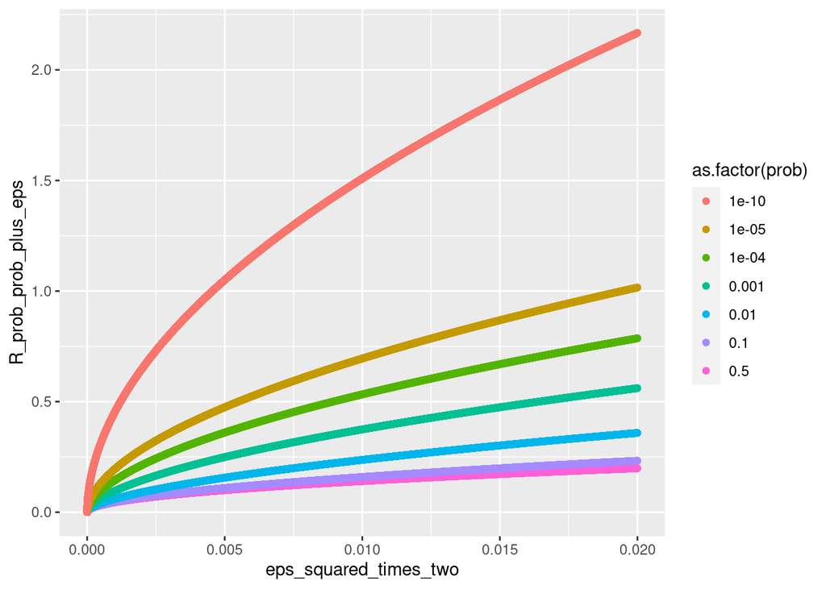

```r
library(magrittr)
epsilon <- (1:10000) / 100000
p <- c(0.5, 0.1, 0.01, 0.001, 0.0001, 0.00001, 1e-10)
tibble::tibble(eps = rep(epsilon, times = length(p)),
               prob = rep(p, each = length(epsilon))) %>%
  dplyr::mutate(eps_squared_times_two = 2 * eps ^ 2) %>%
  dplyr::mutate(R_prob_prob_plus_eps = (prob + eps) * log((prob + eps) / prob) -
                  (1 - prob - eps) * log((1 - prob - eps) / (1 - prob))
                ) %>%
  ggplot2::ggplot() + ggplot2::geom_point(mapping = ggplot2::aes(x = eps_squared_times_two, y = R_prob_prob_plus_eps, colour = as.factor(prob)))
```

Smaller values of $p$ correspond to plots that, near $2\epsilon^2 = 0$, are steeper.

# Exercise 8

# Exercise 9